# Iskander et al, Science Translational Medicine, 2021

Guanlin Wang

##### Figure 2. Features of the erythroid progenitor trajectory differentiate RPS-DBA and RPL-DBA primary human HSPCs.

##### load the library and object

```r
library(SingCellaR)
library(ggplot2)
library(survminer)
load(file = "/Users/gwang/DBA/DBA_revision/DBA_MKE.merged.louvain.rdata")
```

##### A) A UMAP aggregate is shown of all control and DBA EP and MKP cells (n=6380) depicting four distinct subclusters.

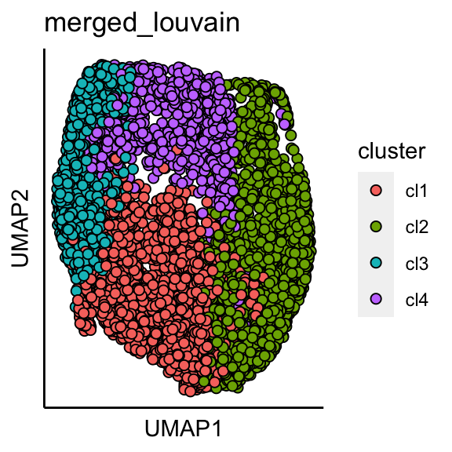

```r
plot_umap_label_by_clusters(DBA_MKE,show_method = "merged_louvain",mark.clusters = F)
```

##### B) A heatmap is shown for the 15 top differentially expressed genes (row labels, right) for each of the four EP and MKP sub-clusters (color-coded columns).Labels across the top indicate cluster assignment according to their marker genes: early erythroid progenitors (EEP), cycling EP (Ecycling), late erythroid progenitors (LEP) and megakaryocyte progenitors (MKP).

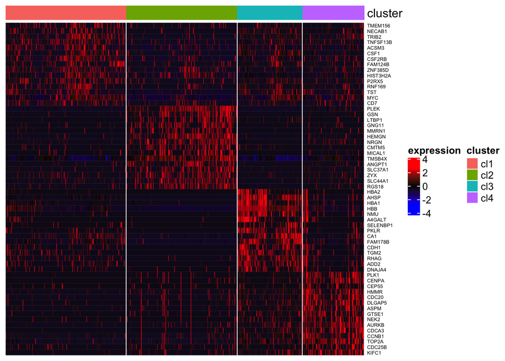

```r
plot_heatmap_for_marker_genes(DBA_MKE,cluster.type = "merged_louvain",isClusterByRow = F,
                              n.TopGenes = 15,min.log2FC = 0.5,min.expFraction = 0.3,
                              rowFont.size = 5,split.line.col = "white")
```

```r
gene.list <- rev(c("GATA2","GATA1","KLF1","FLI1","CD34","TFR2","TFRC","ENG","GYPA","AURKB","MKI67"))


normalized.umi <- get_normalized_umi(DBA_MKE)
cells <- DBA_MKE@umap.result$Cell
normalized.umi <- normalized.umi[gene.list,cells]

umap.results <- DBA_MKE@umap.result
sc.clusters <- DBA_MKE@sc.clusters
umap.results <- umap.results[match(sc.clusters$Cell,umap.results$Cell),]
identical(as.character(umap.results$Cell),as.character(sc.clusters$Cell))
```

```
## [1] TRUE
```

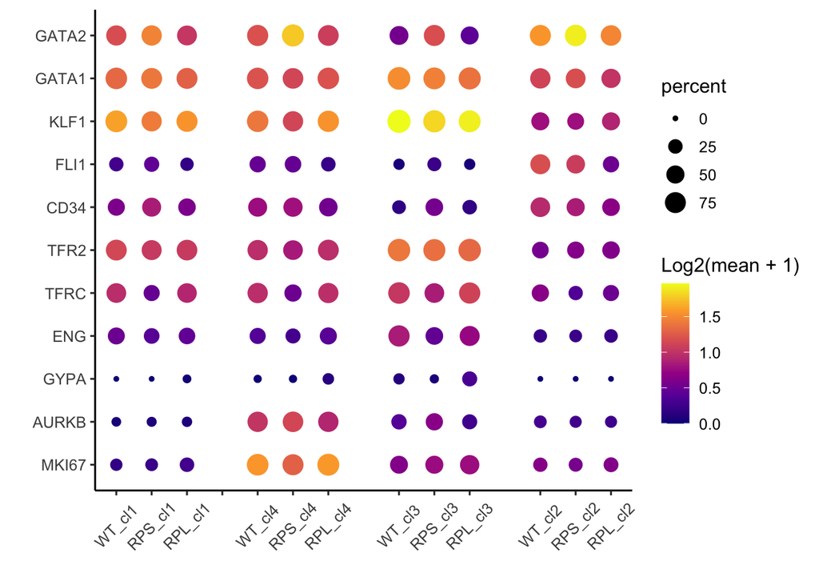

```r
sc.clusters$genotype <- umap.results$genotype
sc.clusters$type <- paste(sc.clusters$genotype,sc.clusters$merged_louvain,sep = "_")
sc.clusters$subset <- as.numeric(factor(sc.clusters$type))


data <- data.frame()
for (i in 1:length(gene.list)){
  gene <- as.character(gene.list[i])
  expr <- normalized.umi[gene,]
  for (j in 1:12){
    cluster.id = j
    cells <- sc.clusters$Cell[sc.clusters$subset == cluster.id]
    used.expr <- expr[names(expr) %in% cells]
    used.expr <- as.numeric(used.expr)
    n.exp <- length(used.expr[used.expr>0])
    expr.fract <- round(n.exp/length(used.expr) *100)
    expr.mean <- mean(used.expr)
    expr.mean <- log2(expr.mean +1)
    mat <- data.frame(gene =gene,subset = cluster.id, percent = expr.fract, expression = expr.mean)
    data <- rbind(data,mat)

  }

}
# data


sc.clusters.used <- sc.clusters[,c("merged_louvain","subset","genotype","type")]
sc.clusters.used <- sc.clusters[!duplicated(sc.clusters.used$type),]

sc.clusters.merged <- merge(data,sc.clusters.used, by.x = "subset",all.x = TRUE)
# sc.clusters.merged



p<- ggplot(sc.clusters.merged,aes(x = type, y = gene, color = expression, size = percent)) +
  geom_point() +
  scale_color_viridis_c(name = 'Log2(mean + 1)',option = "C") +
  scale_x_discrete(limits = c("WT_cl1","RPS_cl1","RPL_cl1","",
                              "WT_cl4","RPS_cl4","RPL_cl4","",
                              "WT_cl3","RPS_cl3","RPL_cl3","",
                              "WT_cl2","RPS_cl2","RPL_cl2")) +
  theme_classic2() +
  theme(axis.text.x = element_text(angle = 45,vjust = 0.5,hjust = 0.5)) +
  xlab("") +
  ylab("")

p
```

##### E) Single cell co-expression of KLF1 and FLI1 is shown for control, RPS-DBA and RPL-DBA EP and MKP cells. The diagonal marks cells with equal expression of both genes. The fraction of cells above and below the diagonal line is shown.

RPS-DBA

note: x-y axis were set as 0-15. The calculations were based on all the cells

```r
umi <- get_normalized_umi(DBA_MKE)
genes <- c("FLI1","KLF1")
cells <- DBA_MKE@umap.result$Cell
used.umi <- umi[rownames(umi) %in% genes,colnames(umi) %in% cells]
dim(used.umi)
```

```
## [1]    2 6380
```

```r
used.umi <- as.data.frame(t(as.matrix(used.umi)))
used.umi$Cell <- rownames(used.umi)
head(used.umi)
```

```
##                              FLI1     KLF1                    Cell
## AAACCCAAGTATGAAC-1_BP04 0.0000000 2.073398 AAACCCAAGTATGAAC-1_BP04
## AAACGAACAATGTCTG-1_BP04 0.0000000 3.773300 AAACGAACAATGTCTG-1_BP04
## AAACGAACACACCGAC-1_BP04 0.2445107 2.689618 AAACGAACACACCGAC-1_BP04
## AAACGAAGTCGTGTTA-1_BP04 0.0000000 2.078426 AAACGAAGTCGTGTTA-1_BP04
## AAACGAATCAAGCCCG-1_BP04 0.0000000 2.271759 AAACGAATCAAGCCCG-1_BP04
## AAACGCTGTGCCTATA-1_BP04 0.0000000 3.889285 AAACGCTGTGCCTATA-1_BP04
```

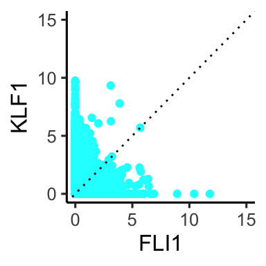

```r
umap.results <- DBA_MKE@umap.result
umi.genotype <- merge(used.umi,umap.results,by = "Cell")

WT.umi <- umi.genotype[umi.genotype$genotype == "WT",]
RPS.umi <- umi.genotype[umi.genotype$genotype == "RPS",]
RPL.umi <- umi.genotype[umi.genotype$genotype == "RPL",]


ggplot(data = WT.umi,aes(x = FLI1, y = KLF1)) +
  geom_point(color = "cyan") +
  xlim(0,15) +
  ylim(0,15) +
  geom_abline(slope = 1,color = "black",linetype = "dotted") +
  theme_classic2()
```

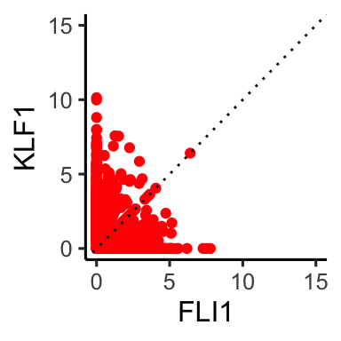

```r
ggplot(data = RPS.umi,aes(x = FLI1, y = KLF1)) +
  geom_point(color = "red") +
  xlim(0,15) +
  ylim(0,15) +
  geom_abline(slope = 1,color = "black",linetype = "dotted") +
  theme_classic2()
```

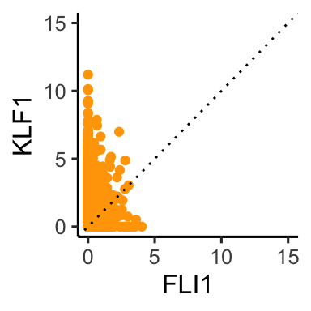

```r
ggplot(data = RPL.umi,aes(x = FLI1, y = KLF1)) +
  geom_point(color = "orange") +
  xlim(0,15) +
  ylim(0,15) +
  geom_abline(slope = 1,color = "black",linetype = "dotted") +
  theme_classic2()
```

```r
WT.umi$deviation <- WT.umi$KLF1 - WT.umi$FLI1
# WT.umi$deviation
WT.p <- length(WT.umi$deviation[WT.umi$deviation >=0])/length(WT.umi$Cell)
WT.p
```

```
## [1] 0.8
```

```r
WT.n <- length(WT.umi$deviation[WT.umi$deviation <0])/length(WT.umi$Cell)
WT.n
```

```
## [1] 0.2
```

```r
RPS.umi$deviation <- RPS.umi$KLF1 - RPS.umi$FLI1
# RPS.umi$deviation
RPS.p <- length(RPS.umi$deviation[RPS.umi$deviation >=0])/length(RPS.umi$Cell)
RPS.p
```

```
## [1] 0.78125
```

```r
RPS.n <- length(RPS.umi$deviation[RPS.umi$deviation <0])/length(RPS.umi$Cell)
RPS.n
```

```
## [1] 0.21875
```

```r
RPL.umi$deviation <- RPL.umi$KLF1 - RPL.umi$FLI1
# RPL.umi$deviation
RPL.p <- length(RPL.umi$deviation[RPL.umi$deviation >=0])/length(RPL.umi$Cell)
RPL.p
```

```
## [1] 0.9457659
```

```r
RPL.n <- length(RPL.umi$deviation[RPL.umi$deviation <0])/length(RPL.umi$Cell)
RPL.n
```

```
## [1] 0.05423406
```